# Inferring cultural transmission from frequency data using the *cTransmission* package

Enrico Crema, Anne Kandler

2019-04-11

# Introduction

The *cTransmission* package provides a framework for inferrring processes of cultural transmssion from observed cultural frequency data.

The inference procedure consists of two steps. First, the researcher has to develop a (non-equilibrium) generative model capturing the main cultural and demographic dynamics of the considered system. This model describes the frequency evolution of different cultural variants present in a population at given time points under an assumed cultural transmission hypothesis. Second, Bayesian techniques in form of approximate Bayesian computation (ABC) are used to derive conclusions about which (mixtures of) transmission strategies are consistent with the observable frequency data and which are not.

The statistical inference process can be carried out in a variety of ways; this vignette will illustrate a workflow based on the *EasyABC* package, which provides multiple flavours of ABC.

We stress that this inference framework is designed to analyse the temporal dynamic of cultural change, defined as the change in frequency of different variants of cultural traits. If the observed data are of a different nature, e.g. describing the continuous variation of certain attributes of cultural artefacts, such as the dimensions of an arrowhead, then researchers have to first construct a hypothesis about the relationship between temporal variation of the attribute and the cultural transmission processes considered in order to apply a similar inference procedure.

We’ll start by installing *cTransmission* and the *EasyABC* package:

```r
devtools::install_github('ercrema/cTransmission')
install.packages('EasyABC')
```

and load them

```r
library(cTransmission)
library(EasyABC)
```

```
## locfit 1.5-9.1    2013-03-22
```

# Data Preparation

In order to create a suitable data set for *cTransmission* we need: 1) A matrix containing the absolute frequencies of each cultural variant at the end of subsequent sampling phases; 2) the time-stamp of the last time step of each sampling phase; and 3) the duration of the sampling windows for all phases except the first (i.e. the number of time step preceding the the last time step of a phase that are assumed to have contributed to the observed frequencies).

We’ll start by creating a matrix of variants frequencies:

```r
# Create an artificial dataset
obs = rbind(c(2, 4, 7, 16, 27, 44, 96, 104, 0, 0, 0, 0),
            c(3, 2, 2, 19, 10, 27, 73,  62, 1, 1, 0 ,0),
            c(0, 4, 0, 17, 7,  47, 80,  82, 0, 0, 2, 1))
colnames(obs) = LETTERS[1:ncol(obs)]
```

The matrix `obs` contains the absolute frequencies of 12 cultural variants collected across 3 sampling phases. The values of the matrix have been generated via simulation, readers interested in the details of the simulation can access the source markdown file of this document. Once we have our matrix with variants frequencies we can run the `cFreqData()` function which will create an object of class `cFreqData` data. This class will be required for other functions of the package:

```r
x = cFreqData(x = obs,timestamp = c(1,30,60), duration = c(10,10))
```

The argument `timestamp` requires a vector of numbers indicating the last timestep of each sampling phase, while the argument `duration` contains the duration of each sampling phase, i.e. the number of time step preceding the the last time step of a phase that are assumed to have contributed to the observed frequencies. This effectively implies that we are assuming that our variant frequency was the outcome of 60 transmission events or *generations*, and that our second phase is a sample of variants produced in *generations* 21 to 30 and our third phase a sample of variants produced in generations 51 to 60. Translating calendar time (e.g. 100 years) into *generations* is not a trivial exercise, and requires additional assumptions on the number of transmission of events over time.

# Creating the generative model

In general, the generative model needs to be designed to capture the main cultural and demographic dynamics of the cultural system. Importantly, the generative model has to produce population-level frequencies of different variants of a cultural trait at different points in time conditioned on the assumed cultural transmission process so that theoretical predictions can be compared to empirical observations. Thereby different transmission processes are expressed by different model parameterizations (those model parameters are summarized in the vector `theta` in the following). In other words, the generative model has to establishes an explicit causal relationship between the assumed cultural transmssion processes (defined by `theta`) and observable population-level patterns of frequency change. There are no restrictions on the type of model used, but importantly it has to be tailored specifically to the observed population-level frequency data and the cultural system considered.

Generative models produced in `cTransmission` can be summarised in the follow steps:

1. Determine population size across all time steps assuming that observed variants are just a fraction $s$ of the population.
2. Define the proportion of $r$ of the population of cultural variants to be replaced in every time step.
3. Determine the population frequencies of the cultural variants in the first phase.
4. Construct a user define transmission model (containing a number of parameters controlling the nature and strengh of the cultural transmission processes) to model the expected frequencies of cultural variants for all sampling phases except the first conditioned on the assumed transmission process, taking into account sampling error and time-averaging.

The `genSim()` function provides a wrapper for all these steps and generates a bespoke R function which can be used for ABC inferences. The example below creates the function `sim()`:

```r
sim = genSim(theta=c("mu","b"), x=x, model=frequencyBias, sMean=0.2, sVariance=0.05, alpha=1, rMean=0.2, rVariance=0.05)
```

The function requires the following arguments:

- `x:` the observed frequency data, time stamps, and durations (i.e. a `CFreqData` class object).
- `sMean:` the mean sampling fraction.
- `sVariance:` the uncertainty in the estimated sampling fraction. If `sVariance` is larger than 0, a random value will be sampled from a truncated normal distribution with mean `sMean`, standard deviation `sVariance` and values between 0 and 1.
- `rMean:` the mean replacement rate.
- `rVariance:` the uncertainty of the estimated replacement rate. If `rVariance` is larger than 0, a random value will be sampled from a truncated normal distribution with mean `rMean`, standard deviation `rVariance` and values between 0 and 1.
- `alpha:` the parameter of the Dirichlet distribution.
- `model:` the transmission model used.
- `theta:` the vector containing the parameters to be estimated.

The resulting function reads a list of parameters values (those defined by the argument `theta`) and produces the expected frequency of cultural variants that are observed during the first phase across the remaining phases. For example:

```r
(res=sim(list(0.05,-0.01)))
```

```
##  [1] 0.24500000 0.16250000 0.27000000 0.25416667 0.13000000 0.12083333
##  [7] 0.08500000 0.07500000 0.02000000 0.04166667 0.03000000 0.01666667
## [13] 0.01000000 0.00000000 0.00500000 0.00000000
```

will run a `frequencyBias` transmission model with an innovation rate of 0.05 and a frequency bias of -0.01 (a mild anti-conformist bias) and generate the frequencies of the 8 cultural variants observed in our first phase. Note that the two first entries describe the frequencies of the first variant at the end of phase two and three, the subsequent two entires the frequencies of the second variant at the end of phase two and three and so on.

These frequencies can then be compared to the observed frequencies:

```r
#observed
observed = round(prop.table(x$cfreq,1),3)[2:3,1:x$k[1]]
#simulated
simulated = round(matrix(res,ncol=8,nrow=2),3)
colnames(simulated) = colnames(observed)

observed
```

```
##          H     G     F     E     D    C     B     A
## [1,] 0.310 0.365 0.135 0.050 0.095 0.01 0.010 0.015
## [2,] 0.342 0.333 0.196 0.029 0.071 0.00 0.017 0.000
```

```r
simulated
```

```
##          H     G     F     E     D     C    B     A
## [1,] 0.245 0.270 0.130 0.085 0.020 0.030 0.01 0.005
## [2,] 0.162 0.254 0.121 0.075 0.042 0.017 0.00 0.000
```

Notice that the argument `theta` can also contain the sampling fraction and/or the replacement rate, in other words the values of additional model parameters can be easily inferred from the data. For example:

```r
sim2 = genSim(theta=c("s","mu","b"), x=x, model=frequencyBias, alpha=1, rMean=0.2, rVariance=0.05)
```

will generate a function (`sim2()`) which would now require as argument the sampling fraction `s`, the innovation rate `mu`, and the frequency bias parameter `b`. Notice that the order in which these parameters are supplied is important, as the output functions of `genSim()` cannot accept named argument.

The next few subsections provide some further details on the internal functions of `genSim()` and how to generate bespoke transmission models. Users interested in making ABC inference with the default frequency bias transmission model can skip to the section Approximate Bayesian Computation via the *EasyABC* package. Nevertheless we stress again that the accuracy of the inference method depends on the appropriatness of the generative model to describe the culutral system considered.

## Estimating Population Sizes

Population size estimates for each time point of the considered time span are obtained from the function `generate_popSize()` which requires as argument the observed frequencies (supplied as a `cFreqData` class object) and the parameters `sMean` and `sVariance`. The function first estimates the sampling fraction $s$ as a random draw from a truncated normal distribution with mean `sMean` and standard deviation `sVariance`. Then it estimates the population size at the end of each sampling phase by dividing the observed sample size by $s$, and computes a linear interpolation accross all time steps of the phases. For example, if we assume $s=0.2$ we would obain:

```r
(pop = generate_popSize(x=x,sMean=0.2,sVariance=0))
```

```
##  [1] 1500 1483 1466 1448 1431 1414 1397 1379 1362 1345 1328 1310 1293 1276
## [15] 1259 1241 1224 1207 1190 1172 1155 1138 1121 1103 1086 1069 1052 1034
## [29] 1017 1000 1007 1013 1020 1027 1033 1040 1047 1053 1060 1067 1073 1080
## [43] 1087 1093 1100 1107 1113 1120 1127 1133 1140 1147 1153 1160 1167 1173
## [57] 1180 1187 1193 1200
```

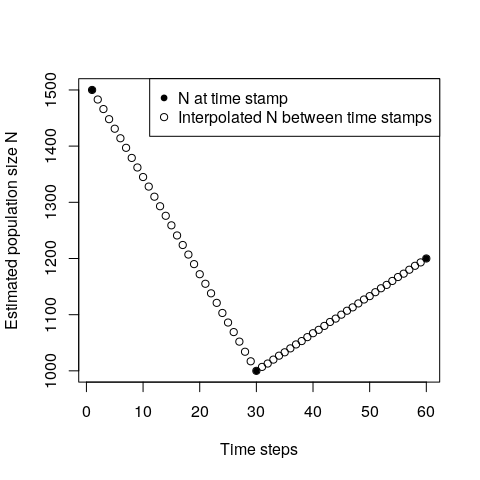

```r
plot(pop,type='b', xlab="Time steps", ylab="Estimated population size N")
points(x$tstamp,x$n/0.2,pch=20,cex=1.2) #x$n is the sample size for each sampling phase, x$tstamp is the timestamp of each sampling phase
legend("topright",legend=c("N at time stamp","Interpolated N between time stamps"),pch=c(20,1),pt.cex=c(1.2,1))
```

where `pop` is a vector with length 60 (corresponding to the number of time steps we assumed) which contains the population size estimates for every step.

## Estimating the frequencies of the cultural variants in the first phase

The observed frequencies of cultural variants in the first phase play a pivotal role in the inferential process offered by `cTransmission` as they define the initial conditions of the generative model created by the `genSim()` function. However, the observed frequencies describe the sample and not the population of cultural variants. The `generate_initialPop()` function utilises a Dirichlet distribution approach to estimate the relative frequency of each cultural variant at the population level. The function requires a vector of observed frequencies and the parameter $\alpha$ of the Dirichlet distribution. Internally `genSim()` supplies a vector of $k+1$ variants, where $k$ is the number of cultural variants observed during the first phase. The component $k+1$ is a placeholder for the estimate of the proportion of variants not observed in the sample.

```r
observedFreq = x$cfreq[1,1:x$k[1]] #extract raw frequencies of observed variant
observedFreq = c(observedFreq,0) #add placeholder for unobserved variants
popFreq = generate_initialPop(observedFreq,alpha=1) # use the Dirichlet distribution to estimate one possible set of variant frequencies
ini = round(popFreq*pop[1]) #compute initial raw frequencies by combining estimates of population size and estimates of variant relative frequencies obtained from generate_initialPop
```

## Computing the number of cultural variants to be removed/added

The `cTransmission` package accounts for the possibility that only a proportion $r$ of the population of cultural variants is replaced in every time step. The `generate_removalReplacement()` function computes the number of cultural variants to be removed (by random sampling) and to be added (via cultural transmssion) at each timestep. The function requires the `cFreqData` class object, the estimated population sizes, and the replacement rate $r$:

```r
rr = generate_removalReplacement(x=x,N=pop,r=0.2)
head(rr)
```

```
##     u   v
## 1 313 296
## 2 310 293
## 3 307 289
## 4 303 286
## 5 299 282
## 6 296 279
```

The resulting data.frame contains the number of objects to be removed (`u`) or and added (`v`) at each timestep.

## Modelling cultural change

Once population structure and size are estimated for the first phase, expected changes in frequency of cultural variants are computed by the `generate_cultural_change()` function. This is actually a wrapper function that combines and feeds the output of `generate_popSize()`, `generate_removalReplacement()`, and `generate_initialPop()` to a transmission model defined by the arguments `model` and `params`. Thereby the argument `model` is a function (in our case `frequencyBias()`) that reads variant frequencies and computes the probability of each variant being chosen for replacement under a particular transmission process — defined by the model parameters supplied by the argument `params` as a list. In the example below, we use a frequency biased transmission model where the magnitude and the direction of the bias is tuned by the parameter $b$ according to the equation:

$$\pi_j = \frac{m_j^{1+b}}{\sum_{s=1}^{k}m_s^{1+b}}(1-\mu)$$
where $\pi_j$ is the probability of chosing variant $j$, $m_j$ the relative frequency of variant $j$, $k$ is the number of different cultural variants, and $\mu$ is the rate of innovation. When $b<0$ the model portrays an anti-conformist biased transmission, when $b>0$ a conformist biased transmission, and when $b=0$ an unbiased transmission.

```r
generate_cultural_change(x=x, iniPop=ini, rr=rr, mu=0.01, params=list(b=0), model=frequencyBias)
```

```
##  [1] 0.380000000 0.304166667 0.315000000 0.308333333 0.080000000
##  [6] 0.075000000 0.100000000 0.079166667 0.025000000 0.050000000
## [11] 0.005000000 0.029166667 0.005000000 0.029166667 0.005000000
## [16] 0.008333333
```

The output of `generate_cultural_change()` is a vector that contains the relative frequencies of the cultural variants presents in the first phase at the end of the two subsequent phases (again the two first entries describe the frequencies of the first variant at the end of phase two and three, the third and fourth entries the frequencies of the second variant at the end of phase two and three and so on).

### Creating a bespoke transmission model

The arguments `model` and `params` provides a flexible structure enabling the possibility of defining custom models of cultural transmission as an R function. This function will need a minimum of two arguments; the absolute frequency of cultural variants `x` and the rate of innovation `mu`. The `generate_cultural_change()` function will then automatically supply these to values to the custom function along with any additional parameters defined in the argument `params`. The custom function should return the probability of chosing each of the cultural variants present.

The script below provides an example of a custom function of a conformist transmission model where there is an additional probability $C$ of selecting the most common cultural variant.

```r
conformistBias <- function(x,mu,C)
{
      x = as.vector(x/sum(x)) # compute proportions
      k = length(x)
      i = which.max(x) #identify the most common variant
      transProb = (1-mu-C)*x # unbiased transmission component
      transProb[i] = transProb[i]+(C)/length(i) #conformist transmission component
      transProb[k] = transProb[k]+mu  #innovation component
      return(transProb)
}
```

which can be supplied as an argument for `generate_cultural_change()`:

```r
generate_cultural_change(x=x, iniPop=ini, rr=rr, mu=0.01, params=list(C=0.1), model=conformistBias)
```

```
##  [1] 0.545000000 0.733333333 0.200000000 0.112500000 0.055000000
##  [6] 0.029166667 0.125000000 0.033333333 0.045000000 0.012500000
## [11] 0.010000000 0.000000000 0.000000000 0.000000000 0.000000000
## [16] 0.004166667
```

# Approximate Bayesian computation via the *EasyABC* package

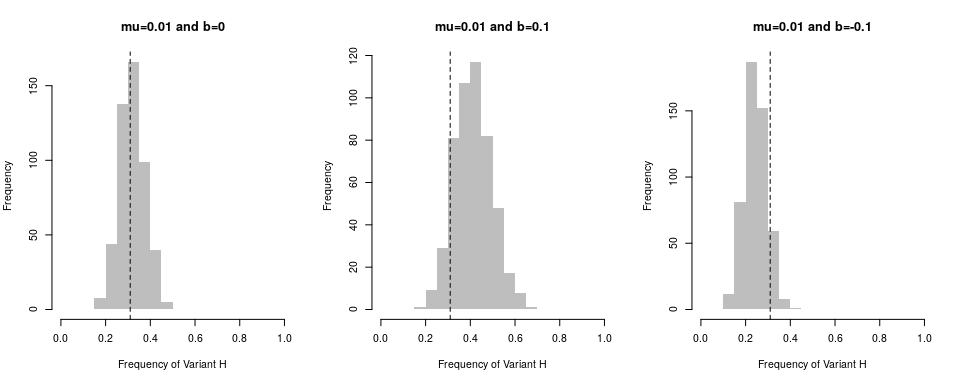

```r
par(mfrow=c(1,3))
hist(replicate(500,sim(list(0.01,0))[1]),breaks=seq(0,1,0.05),border=NA,col='grey',xlab=paste0("Frequency of Variant ",colnames(x$cfreq)[1]),main='mu=0.01 and b=0')
abline(v=x$target.freq[1],lty=2)

hist(replicate(500,sim(list(0.01,0.1))[1]),breaks=seq(0,1,0.05),border=NA,col='grey',xlab=paste0("Frequency of Variant ",colnames(x$cfreq)[1]),main='mu=0.01 and b=0.1')
abline(v=x$target.freq[1],lty=2)

hist(replicate(500,sim(list(0.01,-0.1))[1]),breaks=seq(0,1,0.05),border=NA,col='grey',xlab=paste0("Frequency of Variant ",colnames(x$cfreq)[1]),main='mu=0.01 and b=-0.1')
abline(v=x$target.freq[1],lty=2)
```

The approximate Bayesian computation framework expands this comparison by measuring the Euclidean distance between the frequencies of simulated and the *target* cultural variants (i.e. the variants that were present during the first phase) for a random sample of parameter combinations drawn from user-defined *prior* distributions. The model parameters associated with the subset of simulations yielding the closest fit between observed and target frequencies are then summarised by the *posterior* distribution indicating the range of the parameter space that is able to produce frequency data within a certain tolerance level of the observed data, and consequently the cultural transmission processes that are consistent with the data. We stress that the obtained posterior distribution is only a good approximation of the “true”, posterior distribution for small tolerance levels. Therefore if the obtained tolerance levels (i.e. the Euclidean distance between the frequencies of observed and *target* cultural variants) is large, and cannot be improved upon, the inferred posterior distributions are likely not meaningful. This situation may point to an inadequacy of the model, and therefore the assumed cultural transmission processes, to explain the data. The explanatory value of the obtained posterior distribution can be investigated by posterior predictive checks explained below.

To carry out this inference we use the `EasyABC` package, which provides a variety of algorithms. The example below utilises the *rejection algorithm* which is the most basic and simplest form of ABC where users just need to define the number of simulations (`nb_simul`) and the proportion of runs with the closest fit to the data (`tol`). As for other ABC algorithm the function needs the generative model (`model`), a list defining the parameter priors, and the target values (`summary_stat_target`). In more detail `summary_stat_target` describes a vector containing the observed summary statistics (which is stored in the element `$target.freq` of the `cFreqData` object containing the observed data), in our case the observed frequencies of the cultural variants at phases two and three, that are compared to the output of the generative model. Note that other statistics such as the level of cultural diversity are possible.

The example below examines our dataset `x` using our `sim` model with uniform prior for `mu` ranging between 0.001 and 0.01, and a uniform prior for `b`, ranging between -0.1 and 0.1:

```r
library(EasyABC)
prior = list(prior_mu=c("unif",0.001,0.01), prior_b=c("unif",-0.1,0.1))
res = ABC_rejection(model=sim, prior=prior, tol=0.01, nb_simul=1000, summary_stat_target=x$target.freq)
```

## Parallel Computing

Although the `ABC_rejection` function in `EasyABC` allows for parallel processing, the actual execution does currently not work with simulation models created by the `genSim()` function. The function `abcRej()` can provide a working alternative

```r
res2 = abcRej(x=x, sim.model=sim, ncore=3, nsim=100000, tol=0.01, prior = list(prior_mu=c("unif",0.001,0.01), prior_b=c("unif",-0.1,0.1)))
```

## Analysing the ABC output

The output of the `ABC_rejection()` function contains a data.frame (`$param`) with the posterior samples. The function `plotPost()` provides a quick way to visualise both the marginal and the pairwise joint distribution of the posteriors:

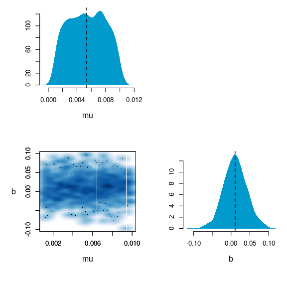

```r
plotPost(res2$unadj.values,pnames = c("mu","b"))
```

The `cTransmission` package also provides a routine for carrying out *posterior predictive checks* to assess how well the parameter ranges specified by the posterior distribution explain the observed data. The `predCheck()` function provides this routine by sampling values of the model parameters from the (joint) posterior distribution, inserting these into the generative model and producing theoretical frequencies at the end of each phase. Repeating this procedure generates theoretical expectations of the frequency ranges for each individual variant type based on the joint posterior distribution. The comparison of the observed frequencies of each variant type with these frequency ranges allowed the explanatory power of the derived posterior distribution to be assessed. If observations are outside the theoretical expectations then the inferred cultural transmssion cannot replicate all aspects of the dynamic of cultural change, indicating a mismatch between theory and data.

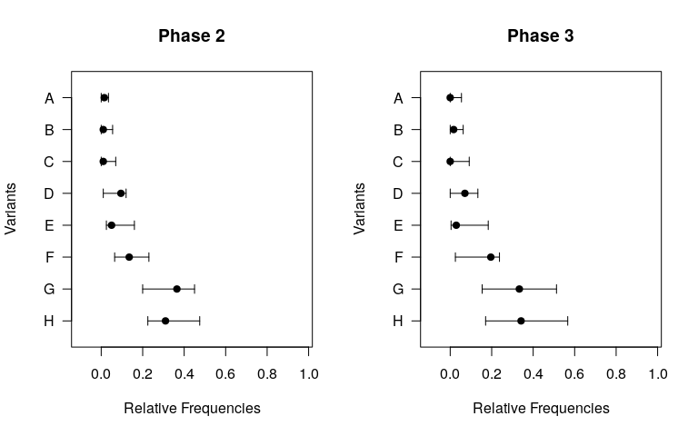

```r
p=predCheck(x,sim,posterior=res2$unadj)

par(mfrow=c(1,2))
plot(p,index=1)
plot(p,index=2)
```